# a3_task3_caitie_reza

Caitie Reza

11/2/2020

### Summary

#### In this document, I will explore, visualize, and statistically analyze purple sea urchin data (urchins.csv) from the Santa Barbara Coastal LTER site. The data was taken as part of the SBC LTER Reef Long-term experiment: Kelp removal: Urchin size frequency distribution. See below for citation:

Santa Barbara Coastal LTER and D. Reed. 2020. SBC LTER: Reef: Long-term experiment: Kelp removal: Urchin size frequency distribution ver 20. Environmental Data Initiative. https://doi.org/10.6073/pasta/5a1e9ef03aa47bd2225c0bb98a02a63b (Accessed 2020-11-03).

```r
urchin_data <- read_csv(here("data", "urchins.csv")) %>%
  clean_names()
```

### Section 1. Comparing Urchin Size

##### In this section, I will explore the sizes of purple and red sea urchins by compare their distributions using several graph types (histogram, boxplot). Then, I will create a table with various summary statistics of the urchins data (read in as “urchin_data”).

#### 1a. Visualization

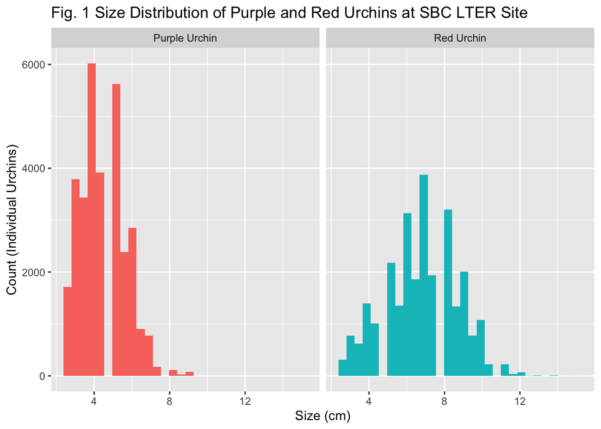

```r
ggplot(data = urchin_data, aes(x = size, fill = common_name)) +
  geom_histogram() +
  facet_wrap(~ common_name) +
  theme(legend.position = "none") +
  labs(x = "Size (cm)", y = "Count (Individual Urchins)",
       title = "Fig. 1 Size Distribution of Purple and Red Urchins at SBC LTER Site")
```

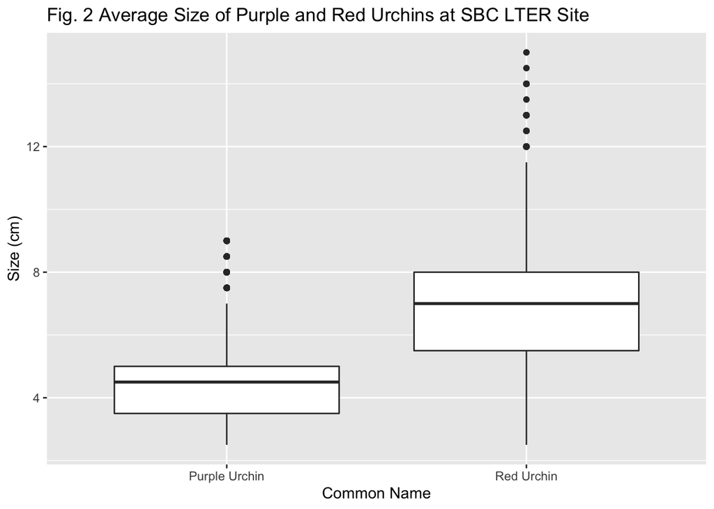

```r
ggplot(data = urchin_data, aes(x = common_name, y = size)) +
  geom_boxplot() +
  labs(x = "Common Name", y = "Size (cm)",
       title = "Fig. 2 Average Size of Purple and Red Urchins at SBC LTER Site") +
  theme_gray()
```

#### 1b. Summary Statistics

Here, I will create a summary table that contains the mean, median, standard deviation, and sample size for purple and red urchins.

```r
urchin_summary <- urchin_data %>%
  group_by(common_name) %>%
  summarize(
    av_size = mean(size),
    median_size = median(size),
    standard_dev = sd(size),
    sample_size = n())
urchin_summary
```

```
## # A tibble: 2 x 5
##   common_name   av_size median_size standard_dev sample_size
##   <chr>           <dbl>       <dbl>        <dbl>       <int>
## 1 Purple Urchin    4.47         4.5         1.18       31805
## 2 Red Urchin       6.78         7           1.89       27408
```

### Section 2. Purple Urchin Counts by Site/Year

In this section, I will be exploring counts of purple urchins at each site by year.

#### 2a. purple_urchin Subset

In a piped sequence, I will create a stored subset of the urchins data called purple_urchins where I: 1) Filter to only include observations for purple urchins 2) Convert the date to class “Date” 3) Create a new column that only contains the year 4) Create a new column called site_full that contains the full name (not abbreviation) for each of the five site

```r
purple_urchins <- urchin_data %>%
  filter(common_name == "Purple Urchin") %>%
  mutate(Date = mdy(date)) %>%
  mutate(Year = year(Date)) %>%
  mutate(site_full = case_when(
     site %in% "NAPL" ~ "Naples Reef",
     site %in% "AQUE" ~ "Arroyo Quemado Reef",
     site %in% "CARP" ~ "Carpinteria Reef",
     site %in% "MOHK" ~ "Mohawk Reef",
     site %in% "IVEE" ~ "Isla Vista Reef"))
```

#### 2b. Purple Urchin Summary Table

Here, I will make a summary table with urchin counts for each site taken each year.

```r
purple_summary <- purple_urchins %>%
  group_by(Year, site_full) %>%
  count(site_full) %>%
  rename("Urchins" = "n")

purple_summary
```

```
## # A tibble: 61 x 3
## # Groups:   Year, site_full [61]
##     Year site_full           Urchins
##    <dbl> <chr>                 <int>
##  1  2008 Arroyo Quemado Reef      67
##  2  2008 Carpinteria Reef        265
##  3  2008 Mohawk Reef             294
##  4  2008 Naples Reef             246
##  5  2009 Arroyo Quemado Reef     926
##  6  2009 Carpinteria Reef       1315
##  7  2009 Mohawk Reef            1344
##  8  2009 Naples Reef            1064
##  9  2010 Arroyo Quemado Reef     921
## 10  2010 Carpinteria Reef        930
## # … with 51 more rows
```

#### 2c. Purple Urchin Graph

Here, I will make 5 separate graphs (one for each site) using ggplot to explore the urchin counts each year at every site, using the table I summarized above. I will use facet_wrap to separate by site.

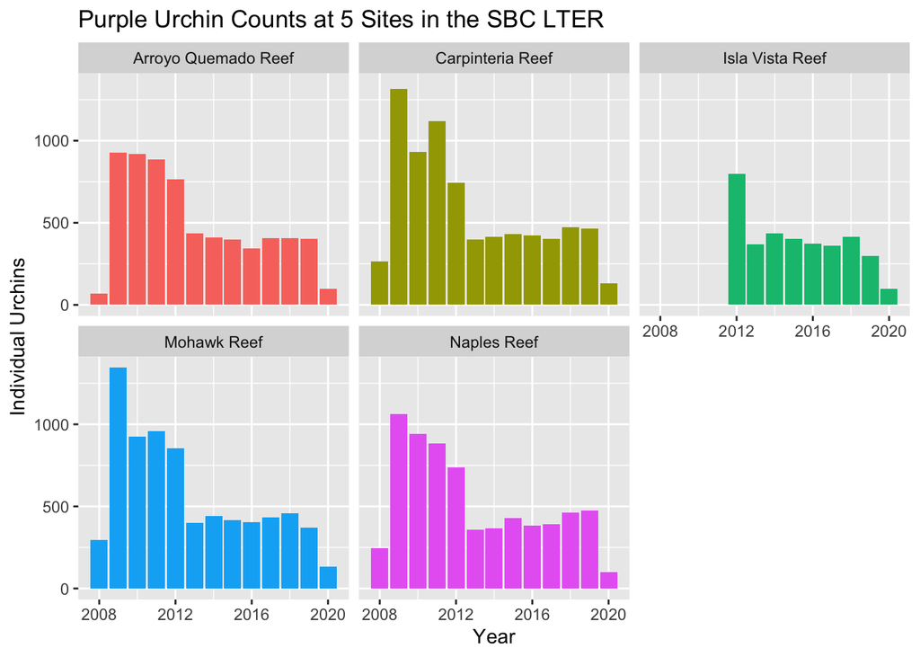

```r
ggplot(data = purple_summary, aes(x = Year, y = Urchins)) +
  geom_col(aes(fill = site_full)) +
  facet_wrap(~site_full) +
  theme(legend.position = "none") +
  labs(y = "Individual Urchins",
       title = "Purple Urchin Counts at 5 Sites in the SBC LTER")
```